# Race-Gen: Disaggregate analyses for P2->RT

Hannah

2/4/2018

## 1. Dissaggregate analyses predicting RT from P2 amplitude

The P2.meancent.scale variable was standardized by subject (i.e., centered around the subject mean and then scaled to have a standard deviation of 1).

### A. Gender categorization task

DV is trial level data. Incorrect trials and trials with +/- 75 uV artifacts are excluded. Subjects with < 50% trials accepted are excluded.  
P2.mean = subject mean (separate subject mean for each electrode)  
P2.meancent.scale = trial level P2 amplitude centered around subject/electrode mean and scaled

Included n = 63 (32 black, 31 white)

#### A1. Disaggregate within and between subject effects:

Between-subjects effect: **P2.mean**  
Within-subjects effect: **P2.meancent.scale**

```
## lmer(formula = RT ~ P2.mean + P2.meancent.scale + (1 | Subject),
##     data = gendat)
```

```
##  Groups   Name        Std.Dev.
##  Subject  (Intercept) 41.765
##  Residual             84.589
```

|  | Estimate | Std. Error | df | t value | Pr(>\|t\|) |
| --- | --- | --- | --- | --- | --- |
| (Intercept) | 457.588 | 5.305 | 63.761 | 86.264 | 0.000 |
| P2.mean | -0.013 | 0.218 | 100290.824 | -0.061 | 0.951 |
| P2.meancent.scale | -2.632 | 0.228 | 137363.022 | -11.553 | 0.000 |

#### A2. Test within-subject relationship by trial type and participant race

```
## lmer(formula = RT ~ P2.mean + P2.meancent.scale * ParRace.e +
##     (1 | Subject), data = gendat)
```

```
##  Groups   Name        Std.Dev.
##  Subject  (Intercept) 42.002
##  Residual             84.585
```

|  | Estimate | Std. Error | df | t value | Pr(>\|t\|) |
| --- | --- | --- | --- | --- | --- |
| (Intercept) | 457.647 | 5.335 | 62.729 | 85.777 | 0.000 |
| P2.mean | -0.018 | 0.218 | 106698.855 | -0.082 | 0.935 |
| P2.meancent.scale | -2.729 | 0.229 | 137362.013 | -11.902 | 0.000 |
| ParRace.e | 2.895 | 5.301 | 61.170 | 0.546 | 0.587 |
| P2.meancent.scale:ParRace.e | 0.857 | 0.229 | 137362.013 | 3.739 | 0.000 |

#####**Black participants:**

```
## lmer(formula = RT ~ P2.mean + P2.meancent.scale * TarRace.e *
##     TarGender.e * Fix.e + (1 | Subject), data = filter(gendat,
##     ParRace == "Black"))
```

```
##  Groups   Name        Std.Dev.
##  Subject  (Intercept) 45.265
##  Residual             83.675
```

|  | Estimate | Std. Error | df | t value | Pr(>\|t\|) |
| --- | --- | --- | --- | --- | --- |
| (Intercept) | 455.050 | 8.032 | 31.342 | 56.652 | 0.000 |
| P2.mean | -0.045 | 0.316 | 56409.077 | -0.143 | 0.886 |
| P2.meancent.scale | -3.600 | 0.340 | 67392.999 | -10.596 | 0.000 |
| TarRace.e | 2.287 | 0.323 | 67393.245 | 7.085 | 0.000 |
| TarGender.e | 0.240 | 0.323 | 67393.417 | 0.743 | 0.458 |
| Fix.e | 1.761 | 0.323 | 67393.173 | 5.457 | 0.000 |
| P2.meancent.scale:TarRace.e | -0.629 | 0.340 | 67393.662 | -1.850 | 0.064 |
| P2.meancent.scale:TarGender.e | 1.379 | 0.340 | 67394.041 | 4.051 | 0.000 |
| TarRace.e:TarGender.e | 8.646 | 0.323 | 67393.449 | 26.773 | 0.000 |
| P2.meancent.scale:Fix.e | 0.267 | 0.341 | 67394.262 | 0.782 | 0.434 |
| TarRace.e:Fix.e | 1.381 | 0.323 | 67393.300 | 4.277 | 0.000 |
| TarGender.e:Fix.e | 1.955 | 0.323 | 67393.290 | 6.058 | 0.000 |
| P2.meancent.scale:TarRace.e:TarGender.e | -2.030 | 0.341 | 67394.091 | -5.961 | 0.000 |
| P2.meancent.scale:TarRace.e:Fix.e | -1.197 | 0.341 | 67394.120 | -3.516 | 0.000 |
| P2.meancent.scale:TarGender.e:Fix.e | -0.988 | 0.340 | 67394.048 | -2.901 | 0.004 |
| TarRace.e:TarGender.e:Fix.e | 1.270 | 0.323 | 67393.253 | 3.936 | 0.000 |
| P2.meancent.scale:TarRace.e:TarGender.e:Fix.e | -0.521 | 0.340 | 67394.030 | -1.531 | 0.126 |

#####**White participants:**

```
## lmer(formula = RT ~ P2.mean + P2.meancent.scale * TarRace.e *
##     TarGender.e * Fix.e + (1 | Subject), data = filter(gendat,
##     ParRace == "White"))
```

```
##  Groups   Name        Std.Dev.
##  Subject  (Intercept) 38.292
##  Residual             84.757
```

|  | Estimate | Std. Error | df | t value | Pr(>\|t\|) |
| --- | --- | --- | --- | --- | --- |
| (Intercept) | 460.432 | 6.981 | 31.689 | 65.954 | 0.000 |
| P2.mean | 0.013 | 0.300 | 48643.082 | 0.044 | 0.965 |
| P2.meancent.scale | -1.943 | 0.307 | 69940.043 | -6.322 | 0.000 |
| TarRace.e | -0.280 | 0.321 | 69940.495 | -0.871 | 0.384 |
| TarGender.e | -0.440 | 0.321 | 69940.458 | -1.370 | 0.171 |
| Fix.e | -0.476 | 0.321 | 69940.319 | -1.481 | 0.139 |
| P2.meancent.scale:TarRace.e | 0.564 | 0.308 | 69941.110 | 1.830 | 0.067 |
| P2.meancent.scale:TarGender.e | -1.023 | 0.308 | 69941.580 | -3.320 | 0.001 |
| TarRace.e:TarGender.e | 3.780 | 0.321 | 69940.639 | 11.762 | 0.000 |
| P2.meancent.scale:Fix.e | -1.033 | 0.309 | 69943.033 | -3.347 | 0.001 |
| TarRace.e:Fix.e | 0.247 | 0.321 | 69940.219 | 0.768 | 0.443 |
| TarGender.e:Fix.e | 0.980 | 0.321 | 69940.368 | 3.051 | 0.002 |
| P2.meancent.scale:TarRace.e:TarGender.e | 0.881 | 0.308 | 69941.311 | 2.859 | 0.004 |
| P2.meancent.scale:TarRace.e:Fix.e | -2.450 | 0.308 | 69941.507 | -7.951 | 0.000 |
| P2.meancent.scale:TarGender.e:Fix.e | 1.040 | 0.308 | 69941.420 | 3.374 | 0.001 |
| TarRace.e:TarGender.e:Fix.e | -0.238 | 0.321 | 69940.239 | -0.740 | 0.459 |
| P2.meancent.scale:TarRace.e:TarGender.e:Fix.e | 0.123 | 0.308 | 69941.784 | 0.397 | 0.691 |

#### A3. Plot simple slopes, separated by race

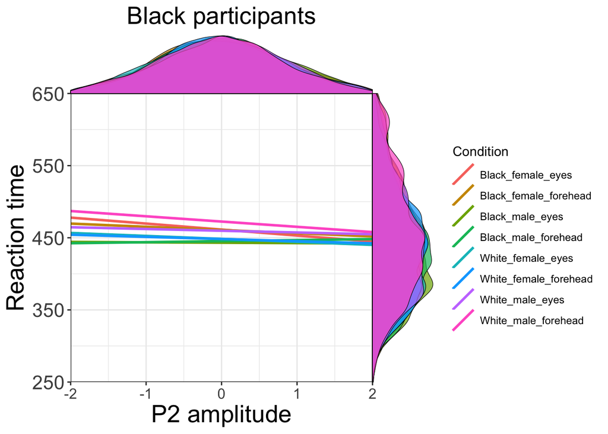

| Target_Race | Target_Gender | Fix | Intercept | Slope | Lower_95%CI | Upper_95%CI |
| --- | --- | --- | --- | --- | --- | --- |
| Black | female | eyes | 461 | -8.31 | -10.24 | -6.38 |
| Black | female | forehead | 461 | -4.45 | -6.40 | -2.50 |
| Black | male | eyes | 443 | -0.56 | -2.34 | 1.22 |
| Black | male | forehead | 445 | 1.44 | -0.55 | 3.42 |
| White | female | eyes | 448 | -4.16 | -5.99 | -2.32 |
| White | female | forehead | 448 | -3.00 | -4.94 | -1.06 |
| White | male | eyes | 460 | -2.44 | -4.44 | -0.44 |
| White | male | forehead | 473 | -7.32 | -9.30 | -5.33 |

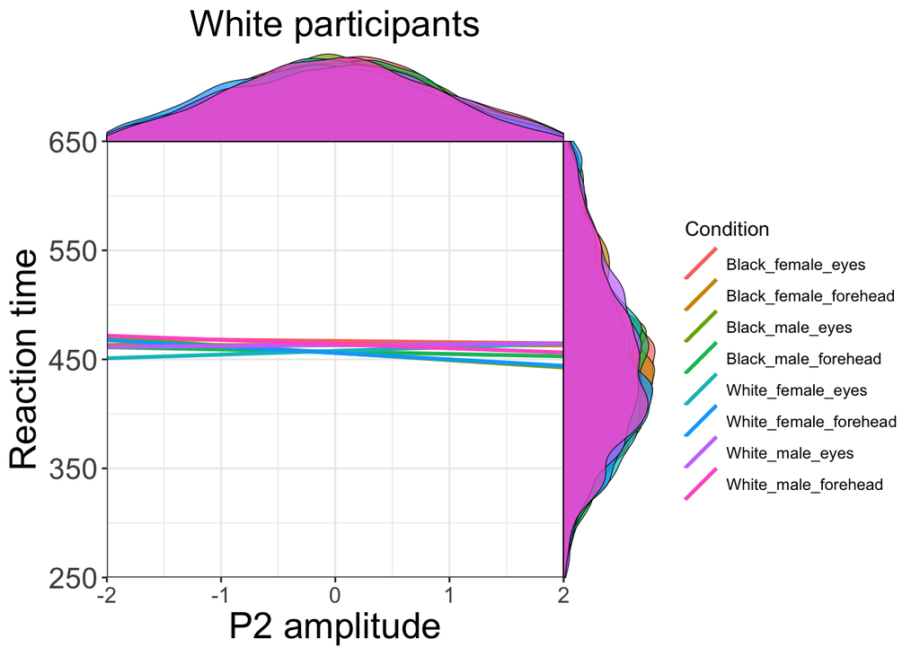

| Target_Race | Target_Gender | Fix | Intercept | Slope | Lower_95%CI | Upper_95%CI |
| --- | --- | --- | --- | --- | --- | --- |
| Black | female | eyes | 467 | -1.10 | -2.83 | 0.62 |
| Black | female | forehead | 463 | -0.10 | -1.81 | 1.60 |
| Black | male | eyes | 456 | -6.74 | -8.53 | -4.96 |
| Black | male | forehead | 457 | -2.08 | -3.86 | -0.29 |
| White | female | eyes | 458 | 3.41 | 1.65 | 5.17 |
| White | female | forehead | 456 | -5.88 | -7.55 | -4.21 |
| White | male | eyes | 463 | 0.80 | -0.86 | 2.46 |
| White | male | forehead | 464 | -3.84 | -5.69 | -1.99 |

**Zoomed in:**

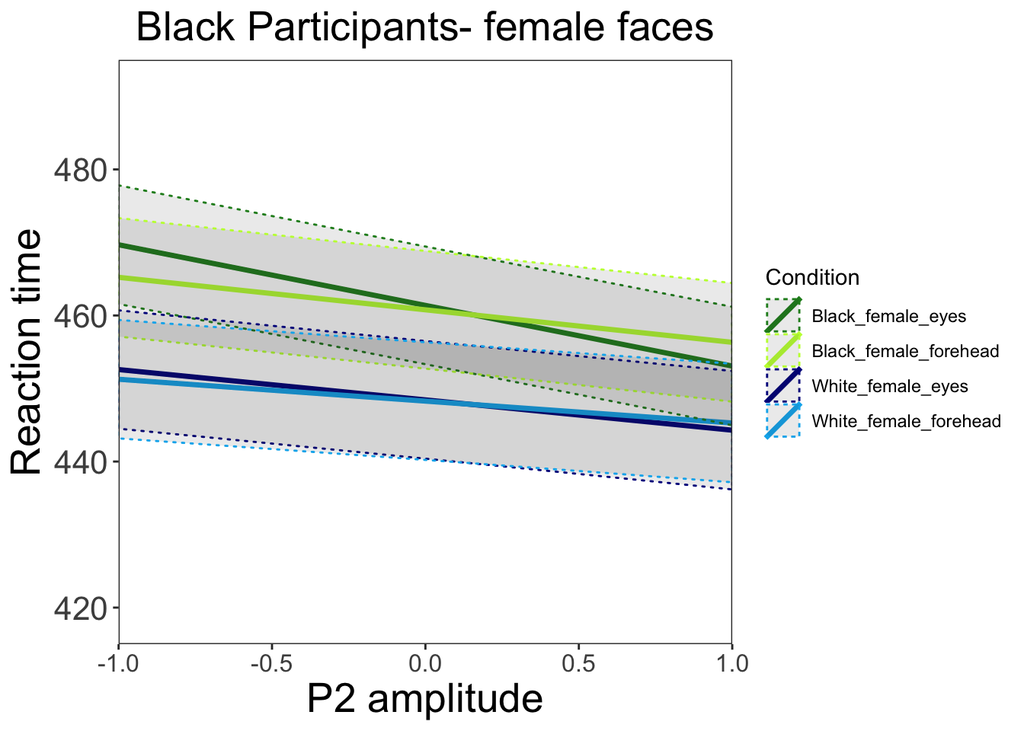

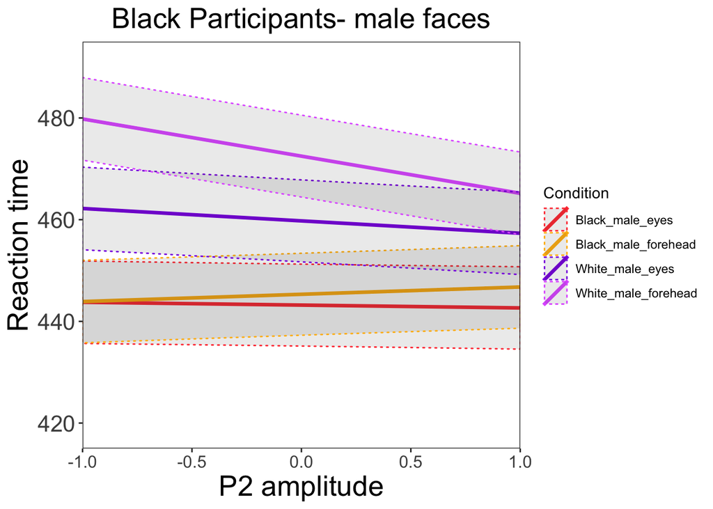

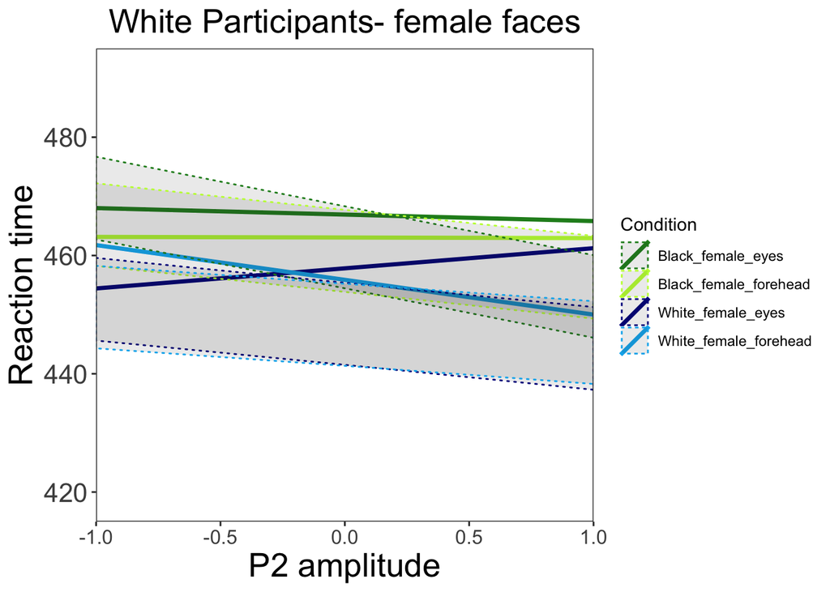

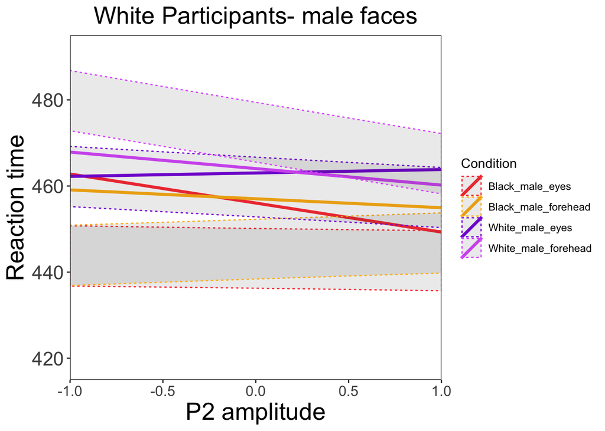

### B. Race categorization task

DV is trial level data. Incorrect trials and trials with +/- 75 uV artifacts are excluded. Subjects with < 50% trials accepted are excluded. P2.mean = subject mean (separate subject mean for each electrode)  
P2.meancent.scale = trial level P2 amplitude centered around subject mean

Included n = 63 (33 black, 30 white)

#### B1. Disaggregate within and between subject effects:

Between-subjects effect: **P2.mean**  
Within-subjects effect: **P2.meancent.scale**

```
## lmer(formula = RT ~ P2.mean + P2.meancent.scale + (1 | Subject),
##     data = racedat)
```

```
##  Groups   Name        Std.Dev.
##  Subject  (Intercept) 49.172
##  Residual             77.561
```

|  | Estimate | Std. Error | df | t value | Pr(>\|t\|) |
| --- | --- | --- | --- | --- | --- |
| (Intercept) | 435.283 | 6.224 | 63.013 | 69.936 | 0.000 |
| P2.mean | -0.010 | 0.200 | 123541.496 | -0.048 | 0.962 |
| P2.meancent.scale | -2.702 | 0.206 | 142743.017 | -13.145 | 0.000 |

#### B2. Test within-subject relationship by trial type and participant race

```
## lmer(formula = RT ~ P2.mean + P2.meancent.scale * ParRace.e +
##     (1 | Subject), data = racedat)
```

```
##  Groups   Name        Std.Dev.
##  Subject  (Intercept) 48.191
##  Residual             77.555
```

|  | Estimate | Std. Error | df | t value | Pr(>\|t\|) |
| --- | --- | --- | --- | --- | --- |
| (Intercept) | 435.857 | 6.109 | 62.048 | 71.352 | 0.000 |
| P2.mean | -0.020 | 0.200 | 124674.469 | -0.100 | 0.920 |
| P2.meancent.scale | -2.791 | 0.206 | 142742.001 | -13.523 | 0.000 |
| ParRace.e | 11.447 | 6.084 | 61.070 | 1.881 | 0.065 |
| P2.meancent.scale:ParRace.e | 0.984 | 0.206 | 142742.001 | 4.767 | 0.000 |

#####**Black participants:**

```
## lmer(formula = RT ~ P2.mean + P2.meancent.scale * TarRace.e *
##     TarGender.e * Fix.e + (1 | Subject), data = filter(racedat,
##     ParRace == "Black"))
```

```
##  Groups   Name        Std.Dev.
##  Subject  (Intercept) 50.985
##  Residual             75.875
```

|  | Estimate | Std. Error | df | t value | Pr(>\|t\|) |
| --- | --- | --- | --- | --- | --- |
| (Intercept) | 424.531 | 8.897 | 32.225 | 47.714 | 0.000 |
| P2.mean | -0.038 | 0.273 | 63306.814 | -0.138 | 0.890 |
| P2.meancent.scale | -3.494 | 0.299 | 71820.997 | -11.668 | 0.000 |
| TarRace.e | 4.730 | 0.284 | 71821.174 | 16.662 | 0.000 |
| TarGender.e | -5.157 | 0.284 | 71821.051 | -18.171 | 0.000 |
| Fix.e | -0.156 | 0.284 | 71821.193 | -0.550 | 0.583 |
| P2.meancent.scale:TarRace.e | -1.076 | 0.300 | 71821.825 | -3.584 | 0.000 |
| P2.meancent.scale:TarGender.e | 0.581 | 0.300 | 71821.910 | 1.935 | 0.053 |
| TarRace.e:TarGender.e | 8.578 | 0.284 | 71821.227 | 30.211 | 0.000 |
| P2.meancent.scale:Fix.e | -0.429 | 0.300 | 71821.807 | -1.428 | 0.153 |
| TarRace.e:Fix.e | -0.966 | 0.284 | 71821.206 | -3.403 | 0.001 |
| TarGender.e:Fix.e | -1.021 | 0.284 | 71821.245 | -3.597 | 0.000 |
| P2.meancent.scale:TarRace.e:TarGender.e | 1.241 | 0.300 | 71821.729 | 4.135 | 0.000 |
| P2.meancent.scale:TarRace.e:Fix.e | -0.577 | 0.300 | 71821.577 | -1.922 | 0.055 |
| P2.meancent.scale:TarGender.e:Fix.e | -0.934 | 0.300 | 71821.807 | -3.111 | 0.002 |
| TarRace.e:TarGender.e:Fix.e | 0.945 | 0.284 | 71821.100 | 3.331 | 0.001 |
| P2.meancent.scale:TarRace.e:TarGender.e:Fix.e | 0.809 | 0.300 | 71821.976 | 2.693 | 0.007 |

#####**White participants:**

```
## lmer(formula = RT ~ P2.mean + P2.meancent.scale * TarRace.e *
##     TarGender.e * Fix.e + (1 | Subject), data = filter(racedat,
##     ParRace == "White"))
```

```
##  Groups   Name        Std.Dev.
##  Subject  (Intercept) 44.925
##  Residual             77.917
```

|  | Estimate | Std. Error | df | t value | Pr(>\|t\|) |
| --- | --- | --- | --- | --- | --- |
| (Intercept) | 447.359 | 8.275 | 29.96 | 54.061 | 0.000 |
| P2.mean | -0.007 | 0.289 | 61993.05 | -0.025 | 0.980 |
| P2.meancent.scale | -1.496 | 0.281 | 70892.02 | -5.325 | 0.000 |
| TarRace.e | 4.620 | 0.293 | 70892.26 | 15.753 | 0.000 |
| TarGender.e | -4.233 | 0.293 | 70892.20 | -14.435 | 0.000 |
| Fix.e | 0.773 | 0.293 | 70892.13 | 2.636 | 0.008 |
| P2.meancent.scale:TarRace.e | -0.888 | 0.282 | 70893.30 | -3.151 | 0.002 |
| P2.meancent.scale:TarGender.e | -0.093 | 0.281 | 70892.57 | -0.329 | 0.742 |
| TarRace.e:TarGender.e | 5.525 | 0.293 | 70892.24 | 18.839 | 0.000 |
| P2.meancent.scale:Fix.e | 0.292 | 0.282 | 70893.06 | 1.037 | 0.300 |
| TarRace.e:Fix.e | -0.669 | 0.293 | 70892.13 | -2.281 | 0.023 |
| TarGender.e:Fix.e | -0.290 | 0.293 | 70892.32 | -0.988 | 0.323 |
| P2.meancent.scale:TarRace.e:TarGender.e | -1.036 | 0.281 | 70892.59 | -3.685 | 0.000 |
| P2.meancent.scale:TarRace.e:Fix.e | 0.061 | 0.282 | 70893.02 | 0.216 | 0.829 |
| P2.meancent.scale:TarGender.e:Fix.e | 0.184 | 0.282 | 70893.19 | 0.654 | 0.513 |
| TarRace.e:TarGender.e:Fix.e | -1.195 | 0.293 | 70892.11 | -4.076 | 0.000 |
| P2.meancent.scale:TarRace.e:TarGender.e:Fix.e | -1.275 | 0.281 | 70892.63 | -4.534 | 0.000 |

#### B3. Plot simple slopes, separated by race

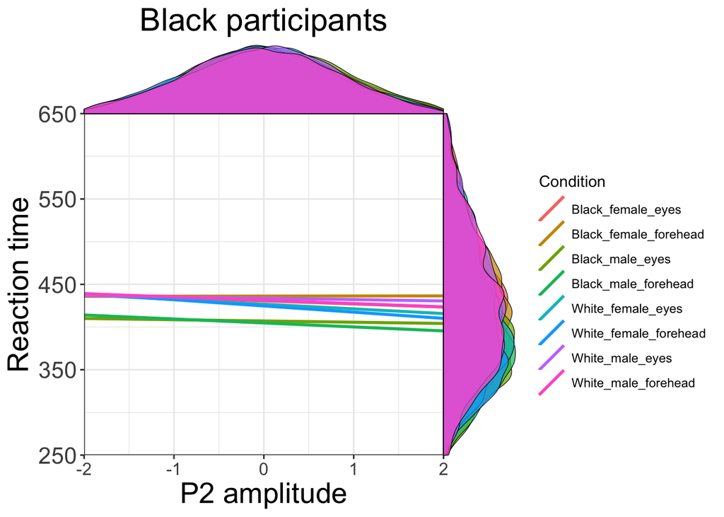

| Target_Race | Target_Gender | Fix | Intercept | Slope | Lower_95%CI | Upper_95%CI |
| --- | --- | --- | --- | --- | --- | --- |
| Black | female | eyes | 431 | -3.65 | -5.38 | -1.91 |
| Black | female | forehead | 436 | 0.13 | -1.56 | 1.83 |
| Black | male | eyes | 407 | -1.48 | -3.09 | 0.12 |
| Black | male | forehead | 405 | -4.67 | -6.45 | -2.90 |
| White | female | eyes | 427 | -5.51 | -7.23 | -3.80 |
| White | female | forehead | 425 | -7.27 | -8.98 | -5.56 |
| White | male | eyes | 434 | -1.62 | -3.35 | 0.11 |
| White | male | forehead | 431 | -3.88 | -5.49 | -2.27 |

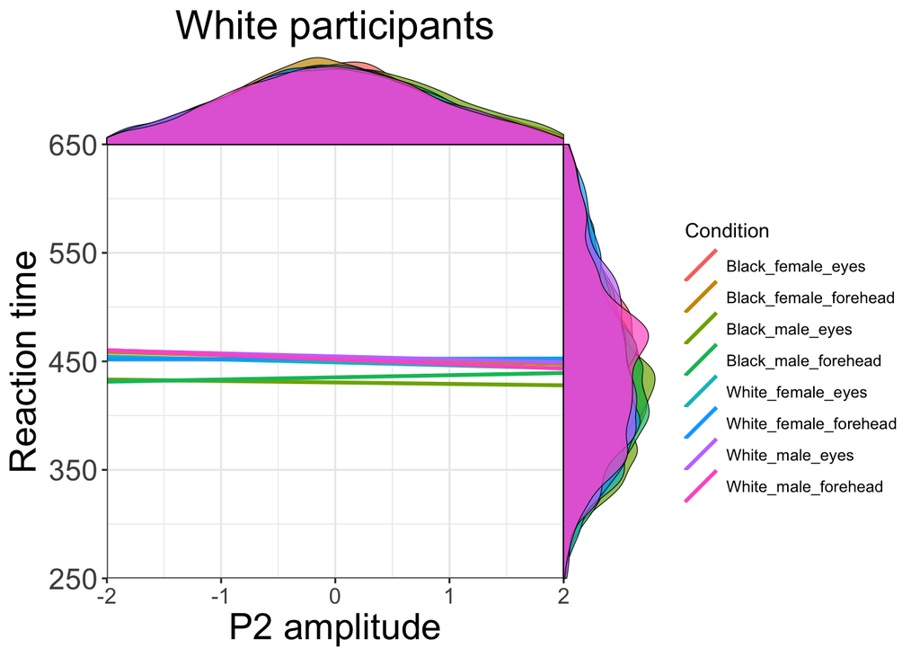

| Target_Race | Target_Gender | Fix | Intercept | Slope | Lower_95%CI | Upper_95%CI |
| --- | --- | --- | --- | --- | --- | --- |
| Black | female | eyes | 452 | -0.32 | -1.94 | 1.29 |
| Black | female | forehead | 453 | -2.78 | -4.50 | -1.06 |
| Black | male | eyes | 431 | -1.35 | -2.87 | 0.16 |
| Black | male | forehead | 435 | 2.03 | 0.42 | 3.64 |
| White | female | eyes | 449 | -2.70 | -4.29 | -1.11 |
| White | female | forehead | 452 | 0.19 | -1.38 | 1.76 |
| White | male | eyes | 455 | -2.77 | -4.31 | -1.23 |
| White | male | forehead | 452 | -4.25 | -5.81 | -2.69 |

**Zoomed in:**

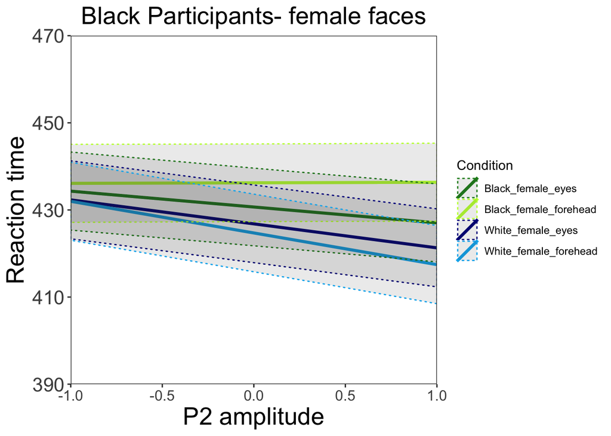

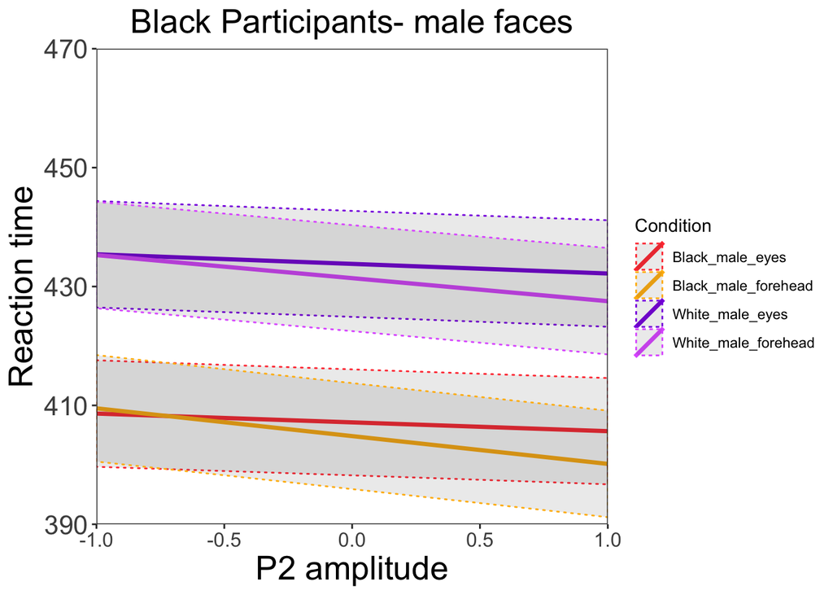

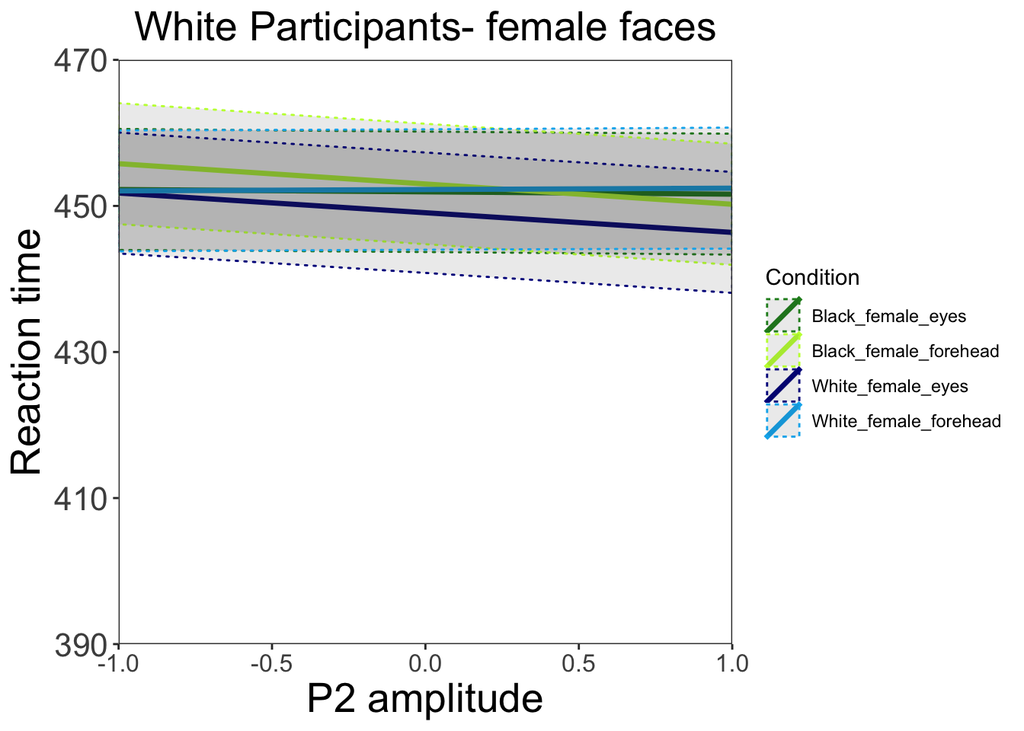

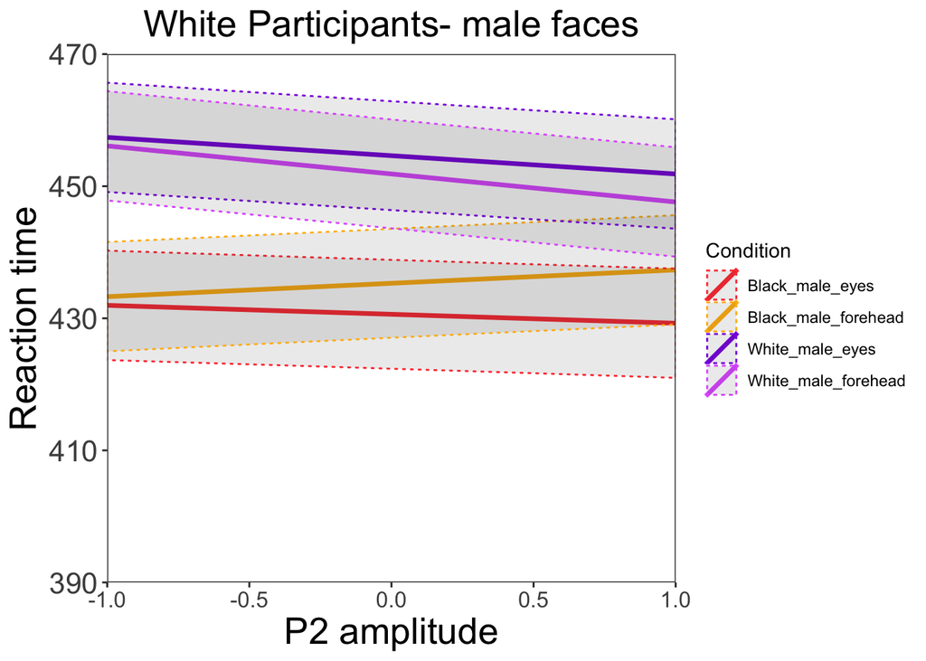

## 2. Examining between/within stimulus group effects

To examine the P2->RT relationship within stimulus type and between stimulus type, I created two new variables. P2.withinSub.betweenStim = mean P2 for each stimulus type, centered within sub P2.withinSub.withinStim = trial level P2, centered within each stim type, centered within sub P2.withinSub.withinStim.scale = trial level P2, centered within each stim type, centered within sub, standardized

### A. Race categorization task

```
## Linear mixed model fit by REML. t-tests use Satterthwaite's method [
## lmerModLmerTest]
## Formula:
## RT ~ P2.mean + P2.withinSub.withinStim + P2.withinSub.betweenStim +
##     (1 | Subject)
##    Data: filter(dat, Task == "Race")
##
## REML criterion at convergence: 1648332
##
## Scaled residuals:
##     Min      1Q  Median      3Q     Max
## -4.3593 -0.6629 -0.1067  0.5414  4.9459
##
## Random effects:
##  Groups   Name        Variance Std.Dev.
##  Subject  (Intercept) 2418     49.17
##  Residual             6011     77.53
## Number of obs: 142808, groups:  Subject, 63
##
## Fixed effects:
##                            Estimate Std. Error         df t value Pr(>|t|)
## (Intercept)               4.353e+02  6.224e+00  6.301e+01  69.936   <2e-16
## P2.mean                  -9.613e-03  2.001e-01  1.236e+05  -0.048    0.962
## P2.withinSub.withinStim  -2.764e-01  2.570e-02  1.427e+05 -10.754   <2e-16
## P2.withinSub.betweenStim -1.540e+00  1.214e-01  1.427e+05 -12.691   <2e-16
##
## (Intercept)              ***
## P2.mean
## P2.withinSub.withinStim  ***
## P2.withinSub.betweenStim ***
## ---
## Signif. codes:  0 '***' 0.001 '**' 0.01 '*' 0.05 '.' 0.1 ' ' 1
##
## Correlation of Fixed Effects:
##              (Intr) P2.men P2.wthnSb.wS
## P2.mean      -0.090
## P2.wthnSb.wS  0.000  0.000
## P2.wthnSb.bS  0.000  0.000  0.000
```

```
## Linear mixed model fit by REML. t-tests use Satterthwaite's method [
## lmerModLmerTest]
## Formula:
## RT ~ P2.mean + P2.withinSub.withinStim.scale + P2.withinSub.betweenStim +
##     (1 | Subject)
##    Data: filter(dat, Task == "Race")
##
## REML criterion at convergence: 1648328
##
## Scaled residuals:
##     Min      1Q  Median      3Q     Max
## -4.3593 -0.6629 -0.1067  0.5414  4.9459
##
## Random effects:
##  Groups   Name        Variance Std.Dev.
##  Subject  (Intercept) 2418     49.17
##  Residual             6011     77.53
## Number of obs: 142808, groups:  Subject, 63
##
## Fixed effects:
##                                 Estimate Std. Error         df t value
## (Intercept)                    4.353e+02  6.224e+00  6.301e+01  69.936
## P2.mean                       -9.613e-03  2.001e-01  1.236e+05  -0.048
## P2.withinSub.withinStim.scale -2.210e+00  2.055e-01  1.427e+05 -10.754
## P2.withinSub.betweenStim      -1.540e+00  1.214e-01  1.427e+05 -12.691
##                               Pr(>|t|)
## (Intercept)                     <2e-16 ***
## P2.mean                          0.962
## P2.withinSub.withinStim.scale   <2e-16 ***
## P2.withinSub.betweenStim        <2e-16 ***
## ---
## Signif. codes:  0 '***' 0.001 '**' 0.01 '*' 0.05 '.' 0.1 ' ' 1
##
## Correlation of Fixed Effects:
##             (Intr) P2.men P2.S.S.
## P2.mean     -0.090
## P2.wthnS.S.  0.000  0.000
## P2.wthnSb.S  0.000  0.000  0.000
```

### B. Gender categorization task

```
## Linear mixed model fit by REML. t-tests use Satterthwaite's method [
## lmerModLmerTest]
## Formula:
## RT ~ P2.mean + P2.withinSub.withinStim + P2.withinSub.betweenStim +
##     (1 | Subject)
##    Data: filter(dat, Task == "Gender")
##
## REML criterion at convergence: 1610156
##
## Scaled residuals:
##     Min      1Q  Median      3Q     Max
## -4.8056 -0.6831 -0.1269  0.5400  4.4710
##
## Random effects:
##  Groups   Name        Variance Std.Dev.
##  Subject  (Intercept) 1744     41.76
##  Residual             7155     84.59
## Number of obs: 137428, groups:  Subject, 63
##
## Fixed effects:
##                            Estimate Std. Error         df t value Pr(>|t|)
## (Intercept)               4.576e+02  5.305e+00  6.376e+01  86.264   <2e-16
## P2.mean                  -1.334e-02  2.183e-01  1.003e+05  -0.061    0.951
## P2.withinSub.withinStim  -3.283e-01  2.849e-02  1.374e+05 -11.526   <2e-16
## P2.withinSub.betweenStim -1.803e-01  1.360e-01  1.374e+05  -1.326    0.185
##
## (Intercept)              ***
## P2.mean
## P2.withinSub.withinStim  ***
## P2.withinSub.betweenStim
## ---
## Signif. codes:  0 '***' 0.001 '**' 0.01 '*' 0.05 '.' 0.1 ' ' 1
##
## Correlation of Fixed Effects:
##              (Intr) P2.men P2.wthnSb.wS
## P2.mean      -0.119
## P2.wthnSb.wS  0.000  0.000
## P2.wthnSb.bS  0.000  0.000  0.000
```

```
## Linear mixed model fit by REML. t-tests use Satterthwaite's method [
## lmerModLmerTest]
## Formula:
## RT ~ P2.mean + P2.withinSub.withinStim.scale + P2.withinSub.betweenStim +
##     (1 | Subject)
##    Data: filter(dat, Task == "Gender")
##
## REML criterion at convergence: 1610152
##
## Scaled residuals:
##     Min      1Q  Median      3Q     Max
## -4.8056 -0.6831 -0.1269  0.5400  4.4710
##
## Random effects:
##  Groups   Name        Variance Std.Dev.
##  Subject  (Intercept) 1744     41.76
##  Residual             7155     84.59
## Number of obs: 137428, groups:  Subject, 63
##
## Fixed effects:
##                                 Estimate Std. Error         df t value
## (Intercept)                    4.576e+02  5.305e+00  6.376e+01  86.264
## P2.mean                       -1.334e-02  2.183e-01  1.003e+05  -0.061
## P2.withinSub.withinStim.scale -2.625e+00  2.278e-01  1.374e+05 -11.526
## P2.withinSub.betweenStim      -1.803e-01  1.360e-01  1.374e+05  -1.326
##                               Pr(>|t|)
## (Intercept)                     <2e-16 ***
## P2.mean                          0.951
## P2.withinSub.withinStim.scale   <2e-16 ***
## P2.withinSub.betweenStim         0.185
## ---
## Signif. codes:  0 '***' 0.001 '**' 0.01 '*' 0.05 '.' 0.1 ' ' 1
##
## Correlation of Fixed Effects:
##             (Intr) P2.men P2.S.S.
## P2.mean     -0.119
## P2.wthnS.S.  0.000  0.000
## P2.wthnSb.S  0.000  0.000  0.000
```